# **Data-Driven Customer Churn Analysis for Olist**

## 1. Project Overview: Customer Retention Analysis for Olist

```python
import pandas as pd
import sqlite3
import glob
import os

base_path = '/Users/jack/Desktop/portfolio/data/olist_ecommerce'

db_path = os.path.join(base_path, 'olist.db')
con = sqlite3.connect(db_path)

csv_path_pattern = os.path.join(base_path, '*.csv')
csv_files = glob.glob(csv_path_pattern)

for file in csv_files:
    table_name = os.path.basename(file).replace('.csv', '').replace('olist_', '').replace('_dataset', '')
    df= pd.read_csv(file)
    df.to_sql(table_name, con, index=False, if_exists='replace')

cursor = con.cursor()
cursor.execute("SELECT name FROM sqlite_master WHERE type = 'table';")
print("Tables in DB: ", cursor.fetchall())
```

```
Tables in DB:  [('sellers',), ('product_category_name_translation',), ('orders',), ('order_items',), ('customers',), ('geolocation',), ('order_payments',), ('order_reviews',), ('products',)]
```

```python
table_to_check = [
    'customers',
    'orders',
    'order_items',
    'products'
]

for table in table_to_check:
    query = f"SELECT * FROM {table} LIMIT 3;"
    df = pd.read_sql_query(query, con)
    print(f"{table} table")
    display(df)
```

```
customers table
```

|  | customer_id | customer_unique_id | customer_zip_code_prefix | customer_city | customer_state |
| --- | --- | --- | --- | --- | --- |
| 0 | 06b8999e2fba1a1fbc88172c00ba8bc7 | 861eff4711a542e4b93843c6dd7febb0 | 14409 | franca | SP |
| 1 | 18955e83d337fd6b2def6b18a428ac77 | 290c77bc529b7ac935b93aa66c333dc3 | 9790 | sao bernardo do campo | SP |
| 2 | 4e7b3e00288586ebd08712fdd0374a03 | 060e732b5b29e8181a18229c7b0b2b5e | 1151 | sao paulo | SP |

```
orders table
```

|  | order_id | customer_id | order_status | order_purchase_timestamp | order_approved_at | order_delivered_carrier_date | order_delivered_customer_date | order_estimated_delivery_date |
| --- | --- | --- | --- | --- | --- | --- | --- | --- |
| 0 | e481f51cbdc54678b7cc49136f2d6af7 | 9ef432eb6251297304e76186b10a928d | delivered | 2017-10-02 10:56:33 | 2017-10-02 11:07:15 | 2017-10-04 19:55:00 | 2017-10-10 21:25:13 | 2017-10-18 00:00:00 |
| 1 | 53cdb2fc8bc7dce0b6741e2150273451 | b0830fb4747a6c6d20dea0b8c802d7ef | delivered | 2018-07-24 20:41:37 | 2018-07-26 03:24:27 | 2018-07-26 14:31:00 | 2018-08-07 15:27:45 | 2018-08-13 00:00:00 |
| 2 | 47770eb9100c2d0c44946d9cf07ec65d | 41ce2a54c0b03bf3443c3d931a367089 | delivered | 2018-08-08 08:38:49 | 2018-08-08 08:55:23 | 2018-08-08 13:50:00 | 2018-08-17 18:06:29 | 2018-09-04 00:00:00 |

```
order_items table
```

|  | order_id | order_item_id | product_id | seller_id | shipping_limit_date | price | freight_value |
| --- | --- | --- | --- | --- | --- | --- | --- |
| 0 | 00010242fe8c5a6d1ba2dd792cb16214 | 1 | 4244733e06e7ecb4970a6e2683c13e61 | 48436dade18ac8b2bce089ec2a041202 | 2017-09-19 09:45:35 | 58.9 | 13.29 |
| 1 | 00018f77f2f0320c557190d7a144bdd3 | 1 | e5f2d52b802189ee658865ca93d83a8f | dd7ddc04e1b6c2c614352b383efe2d36 | 2017-05-03 11:05:13 | 239.9 | 19.93 |
| 2 | 000229ec398224ef6ca0657da4fc703e | 1 | c777355d18b72b67abbeef9df44fd0fd | 5b51032eddd242adc84c38acab88f23d | 2018-01-18 14:48:30 | 199.0 | 17.87 |

```
products table
```

|  | product_id | product_category_name | product_name_lenght | product_description_lenght | product_photos_qty | product_weight_g | product_length_cm | product_height_cm | product_width_cm |
| --- | --- | --- | --- | --- | --- | --- | --- | --- | --- |
| 0 | 1e9e8ef04dbcff4541ed26657ea517e5 | perfumaria | 40.0 | 287.0 | 1.0 | 225.0 | 16.0 | 10.0 | 14.0 |
| 1 | 3aa071139cb16b67ca9e5dea641aaa2f | artes | 44.0 | 276.0 | 1.0 | 1000.0 | 30.0 | 18.0 | 20.0 |
| 2 | 96bd76ec8810374ed1b65e291975717f | esporte_lazer | 46.0 | 250.0 | 1.0 | 154.0 | 18.0 | 9.0 | 15.0 |

```python
query = """
    SELECT *
    FROM orders o
    LEFT JOIN customers c USING(customer_id)
    WHERE o.order_purchase_timestamp IS NOT NULL;
"""
orders_df = pd.read_sql_query(query, con)

orders_df.info()
```

```
<class 'pandas.core.frame.DataFrame'>
RangeIndex: 99441 entries, 0 to 99440
Data columns (total 12 columns):
 #   Column                         Non-Null Count  Dtype
---  ------                         --------------  -----
 0   order_id                       99441 non-null  object
 1   customer_id                    99441 non-null  object
 2   order_status                   99441 non-null  object
 3   order_purchase_timestamp       99441 non-null  object
 4   order_approved_at              99281 non-null  object
 5   order_delivered_carrier_date   97658 non-null  object
 6   order_delivered_customer_date  96476 non-null  object
 7   order_estimated_delivery_date  99441 non-null  object
 8   customer_unique_id             99441 non-null  object
 9   customer_zip_code_prefix       99441 non-null  int64
 10  customer_city                  99441 non-null  object
 11  customer_state                 99441 non-null  object
dtypes: int64(1), object(11)
memory usage: 9.1+ MB
```

```python
time_cols = [
    'order_purchase_timestamp',
    'order_approved_at',
    'order_delivered_carrier_date',
    'order_delivered_customer_date',
    'order_estimated_delivery_date'
]

for col in time_cols:
    orders_df[col] = pd.to_datetime(orders_df[col], errors='coerce')

orders_df.info()
display(orders_df.head())
```

```
<class 'pandas.core.frame.DataFrame'>
RangeIndex: 99441 entries, 0 to 99440
Data columns (total 12 columns):
 #   Column                         Non-Null Count  Dtype
---  ------                         --------------  -----
 0   order_id                       99441 non-null  object
 1   customer_id                    99441 non-null  object
 2   order_status                   99441 non-null  object
 3   order_purchase_timestamp       99441 non-null  datetime64[ns]
 4   order_approved_at              99281 non-null  datetime64[ns]
 5   order_delivered_carrier_date   97658 non-null  datetime64[ns]
 6   order_delivered_customer_date  96476 non-null  datetime64[ns]
 7   order_estimated_delivery_date  99441 non-null  datetime64[ns]
 8   customer_unique_id             99441 non-null  object
 9   customer_zip_code_prefix       99441 non-null  int64
 10  customer_city                  99441 non-null  object
 11  customer_state                 99441 non-null  object
dtypes: datetime64[ns](5), int64(1), object(6)
memory usage: 9.1+ MB
```

|  | order_id | customer_id | order_status | order_purchase_timestamp | order_approved_at | order_delivered_carrier_date | order_delivered_customer_date | order_estimated_delivery_date | customer_unique_id | customer_zip_code_prefix | customer_city | customer_state |
| --- | --- | --- | --- | --- | --- | --- | --- | --- | --- | --- | --- | --- |
| 0 | e481f51cbdc54678b7cc49136f2d6af7 | 9ef432eb6251297304e76186b10a928d | delivered | 2017-10-02 10:56:33 | 2017-10-02 11:07:15 | 2017-10-04 19:55:00 | 2017-10-10 21:25:13 | 2017-10-18 | 7c396fd4830fd04220f754e42b4e5bff | 3149 | sao paulo | SP |
| 1 | 53cdb2fc8bc7dce0b6741e2150273451 | b0830fb4747a6c6d20dea0b8c802d7ef | delivered | 2018-07-24 20:41:37 | 2018-07-26 03:24:27 | 2018-07-26 14:31:00 | 2018-08-07 15:27:45 | 2018-08-13 | af07308b275d755c9edb36a90c618231 | 47813 | barreiras | BA |
| 2 | 47770eb9100c2d0c44946d9cf07ec65d | 41ce2a54c0b03bf3443c3d931a367089 | delivered | 2018-08-08 08:38:49 | 2018-08-08 08:55:23 | 2018-08-08 13:50:00 | 2018-08-17 18:06:29 | 2018-09-04 | 3a653a41f6f9fc3d2a113cf8398680e8 | 75265 | vianopolis | GO |
| 3 | 949d5b44dbf5de918fe9c16f97b45f8a | f88197465ea7920adcdbec7375364d82 | delivered | 2017-11-18 19:28:06 | 2017-11-18 19:45:59 | 2017-11-22 13:39:59 | 2017-12-02 00:28:42 | 2017-12-15 | 7c142cf63193a1473d2e66489a9ae977 | 59296 | sao goncalo do amarante | RN |
| 4 | ad21c59c0840e6cb83a9ceb5573f8159 | 8ab97904e6daea8866dbdbc4fb7aad2c | delivered | 2018-02-13 21:18:39 | 2018-02-13 22:20:29 | 2018-02-14 19:46:34 | 2018-02-16 18:17:02 | 2018-02-26 | 72632f0f9dd73dfee390c9b22eb56dd6 | 9195 | santo andre | SP |

### 2. Quantifying the Business Problem: Retention Analysis

To confirm churn is a real and persistent issue, we first need to measure it.  
We'll apply two key frameworks:

1. **AARRR Funnel** – Identify the stage with the biggest drop-off.
2. **Cohort Analysis** – Track how customer loyalty changes over time.

```python
orders_df.sort_values(by=['customer_unique_id', 'order_purchase_timestamp'], inplace=True)

first_orders_df = orders_df.drop_duplicates(subset='customer_unique_id', keep='first').copy()

display(first_orders_df[['customer_unique_id', 'order_id', 'order_purchase_timestamp']].head())
```

|  | customer_unique_id | order_id | order_purchase_timestamp |
| --- | --- | --- | --- |
| 52798 | 0000366f3b9a7992bf8c76cfdf3221e2 | e22acc9c116caa3f2b7121bbb380d08e | 2018-05-10 10:56:27 |
| 73889 | 0000b849f77a49e4a4ce2b2a4ca5be3f | 3594e05a005ac4d06a72673270ef9ec9 | 2018-05-07 11:11:27 |
| 26460 | 0000f46a3911fa3c0805444483337064 | b33ec3b699337181488304f362a6b734 | 2017-03-10 21:05:03 |
| 98493 | 0000f6ccb0745a6a4b88665a16c9f078 | 41272756ecddd9a9ed0180413cc22fb6 | 2017-10-12 20:29:41 |
| 41564 | 0004aac84e0df4da2b147fca70cf8255 | d957021f1127559cd947b62533f484f7 | 2017-11-14 19:45:42 |

```python
acquisition_cnt = first_orders_df['customer_unique_id'].nunique()
activation_cnt = first_orders_df[first_orders_df['order_status'] == 'delivered']['customer_unique_id'].nunique()

query = """
SELECT c.customer_unique_id
     , COUNT(o.order_id) AS order_cnt
FROM customers c
INNER JOIN orders o USING(customer_id)
GROUP BY customer_unique_id
"""
order_cnt_df = pd.read_sql_query(query, con)
retention_cnt = order_cnt_df[order_cnt_df['order_cnt'] >=2]['customer_unique_id'].nunique()

funnel_data = {
    'Stage': ['1. Acquisition', '2. Activation (First Order Delivered)', '3. Retention (2+ orders)'],
    'User Count': [acquisition_cnt, activation_cnt, retention_cnt]
}
funnel_df = pd.DataFrame(funnel_data)
funnel_df['CVR (from Previous)'] = (funnel_df['User Count'] / funnel_df['User Count'].shift(1)*100)
funnel_df['CVR (from Total)'] = (funnel_df['User Count'] / funnel_df['User Count'].iloc[0]*100)

display(funnel_df.round(2))
```

|  | Stage | User Count | CVR (from Previous) | CVR (from Total) |
| --- | --- | --- | --- | --- |
| 0 | 1. Acquisition | 96096 | NaN | 100.00 |
| 1 | 2. Activation (First Order Delivered) | 93253 | 97.04 | 97.04 |
| 2 | 3. Retention (2+ orders) | 2997 | 3.21 | 3.12 |

### Funnel Insight

Out of 96k users:

- 97% received their first order.
- Only 3% returned for a second.

**Retention is the biggest drop-off point.**

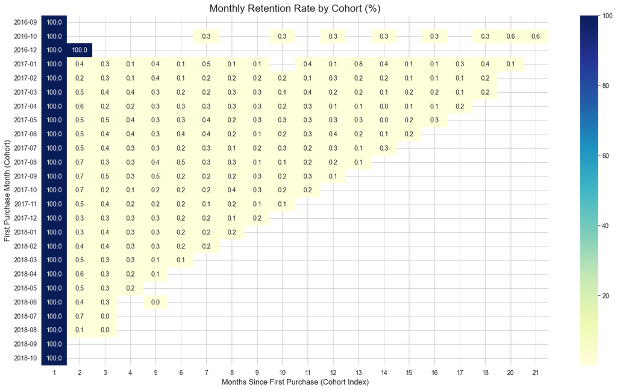

```python
import matplotlib.pyplot as plt
import seaborn as sns

first_purchase_dates = orders_df.groupby('customer_unique_id')['order_purchase_timestamp'].min().reset_index()
first_purchase_dates.columns = ['customer_unique_id', 'first_purchase_date']

cohort_df = pd.merge(orders_df, first_purchase_dates, on='customer_unique_id')
cohort_df['CohortMonth'] = cohort_df['first_purchase_date'].dt.to_period('M')
order_month = cohort_df['order_purchase_timestamp'].dt.to_period('M')
cohort_df['CohortIndex'] = (order_month.dt.year - cohort_df['CohortMonth'].dt.year) * 12 + (order_month.dt.month - cohort_df['CohortMonth'].dt.month) + 1

cohort_data =cohort_df.groupby(['CohortMonth', 'CohortIndex'])['customer_unique_id'].nunique().reset_index()
cohort_counts = cohort_data.pivot_table(index='CohortMonth', columns='CohortIndex', values='customer_unique_id')
cohort_sizes = cohort_counts.iloc[:, 0]
retention_metrix = cohort_counts.divide(cohort_sizes, axis=0)

retention_heatmap_data = retention_metrix * 100
plt.figure(figsize=(18, 10))
sns.heatmap(retention_heatmap_data, annot=True, fmt='.1f', cmap='YlGnBu')
plt.title('Monthly Retention Rate by Cohort (%)', fontsize=16)
plt.xlabel('Months Since First Purchase (Cohort Index)', fontsize=12)
plt.ylabel('First Purchase Month (Cohort)', fontsize=12)
plt.show()
```

### Insight from Monthly Cohort Heatmap

- Monthly return rate per cohort is **below 1%**.
- Shows why total retention stays under 4%:  
  **Few customers return even once.**

### 3-1. Hypothesis: Why Don’t Customers Return?

Three possible causes:

Next: Testing **delivery experience**, our leading suspect.

Create new metrics to measure the efficiency of the delivery process:

- `delivery_time`: The total time (in days) a customer waits for their product.
- `delivery_diff`: The difference (in days) between the promised delivery date and the actual delivery date.

```python
orders_df['delivery_time'] = (orders_df['order_delivered_customer_date'] - orders_df['order_purchase_timestamp']).dt.days

orders_df['delivery_diff'] = (orders_df['order_estimated_delivery_date'] - orders_df['order_delivered_customer_date']).dt.days

display(orders_df[[
    'order_purchase_timestamp',
    'order_delivered_customer_date',
    'order_estimated_delivery_date',
    'delivery_time',
    'delivery_diff'
]].head())
```

|  | order_purchase_timestamp | order_delivered_customer_date | order_estimated_delivery_date | delivery_time | delivery_diff |
| --- | --- | --- | --- | --- | --- |
| 52798 | 2018-05-10 10:56:27 | 2018-05-16 20:48:37 | 2018-05-21 | 6.0 | 4.0 |
| 73889 | 2018-05-07 11:11:27 | 2018-05-10 18:02:42 | 2018-05-15 | 3.0 | 4.0 |
| 26460 | 2017-03-10 21:05:03 | 2017-04-05 14:38:47 | 2017-04-07 | 25.0 | 1.0 |
| 98493 | 2017-10-12 20:29:41 | 2017-11-01 21:23:05 | 2017-11-13 | 20.0 | 11.0 |
| 41564 | 2017-11-14 19:45:42 | 2017-11-27 23:08:56 | 2017-12-05 | 13.0 | 7.0 |

```python
display(orders_df[['delivery_time', 'delivery_diff']].describe())
```

|  | delivery_time | delivery_diff |
| --- | --- | --- |
| count | 96476.000000 | 96476.000000 |
| mean | 12.094086 | 10.876881 |
| std | 9.551746 | 10.183854 |
| min | 0.000000 | -189.000000 |
| 25% | 6.000000 | 6.000000 |
| 50% | 10.000000 | 11.000000 |
| 75% | 15.000000 | 16.000000 |
| max | 209.000000 | 146.000000 |

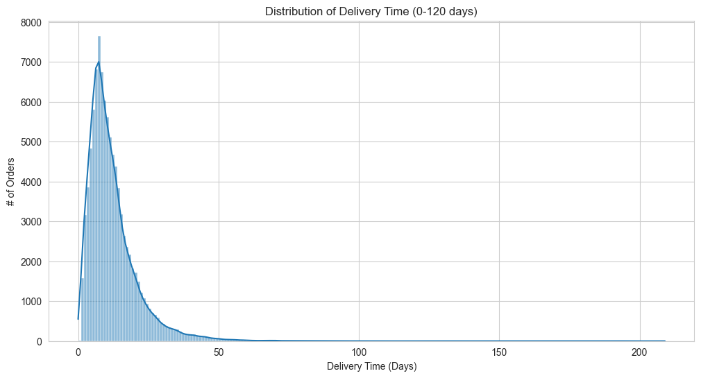

```python
sns.set_style('whitegrid')
plt.figure(figsize=(12, 6))

sns.histplot(orders_df['delivery_time'].dropna(), bins=120, kde=True, binrange=(0, 120))

plt.title('Distribution of Delivery Time (0-120 days)')
plt.xlabel('Delivery Time (Days)')
plt.ylabel('# of Orders')
plt.show()
```

### Analysis

- Most orders are delivered within **5–15 days**.
- The distribution is **right-skewed**, with a **long tail** of very late deliveries.
- These outliers suggest **delivery delays** may affect **customer churn**.

```python
query = """
WITH BASE as(
SELECT DISTINCT c.customer_unique_id
     , o.order_id
FROM customers c
INNER JOIN orders o USING(customer_id)
)

SELECT customer_unique_id
     , CASE WHEN COUNT(order_id) >= 2 THEN 1 ELSE 0 END AS is_retained
FROM BASE
GROUP BY customer_unique_id
"""

retention_df = pd.read_sql_query(query, con)

display(retention_df.head())
```

|  | customer_unique_id | is_retained |
| --- | --- | --- |
| 0 | 0000366f3b9a7992bf8c76cfdf3221e2 | 0 |
| 1 | 0000b849f77a49e4a4ce2b2a4ca5be3f | 0 |
| 2 | 0000f46a3911fa3c0805444483337064 | 0 |
| 3 | 0000f6ccb0745a6a4b88665a16c9f078 | 0 |
| 4 | 0004aac84e0df4da2b147fca70cf8255 | 0 |

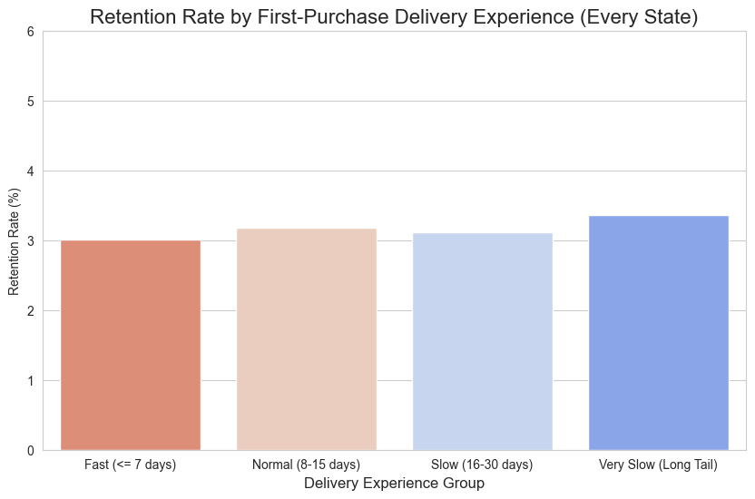

```python
def get_delivery_group(days):
    if days is None:
        return 'Unknown'
    if days <= 7:
        return 'Fast (<= 7 days)'
    elif 8 <= days <= 15:
        return 'Normal (8-15 days)'
    elif 16 <= days <= 30:
        return 'Slow (16-30 days)'
    else:
        return 'Very Slow (Long Tail)'

orders_df['delivery_time'] = pd.to_numeric(orders_df['delivery_time'], errors='coerce')
orders_df['delivery_group'] = orders_df['delivery_time'].apply(get_delivery_group)

first_order_experience_df = pd.merge(first_orders_df[['customer_unique_id', 'order_id']], orders_df[['order_id', 'delivery_group', 'customer_state']], on='order_id', how='left')

final_delivery_analysis_df = pd.merge(first_order_experience_df, retention_df, on='customer_unique_id')

final_delivery_analysis_df = final_delivery_analysis_df[final_delivery_analysis_df['delivery_group'] != 'Unknown']

retention_by_delivery_group = final_delivery_analysis_df.groupby('delivery_group')['is_retained'].mean().sort_values(ascending=False) * 100

group_order = ['Fast (<= 7 days)', 'Normal (8-15 days)', 'Slow (16-30 days)', 'Very Slow (Long Tail)']
retention_by_delivery_group = retention_by_delivery_group.reindex(group_order)

plt.figure(figsize=(10, 6))
sns.barplot(x=retention_by_delivery_group.index, y=retention_by_delivery_group.values, palette='coolwarm_r', order=group_order)
plt.title('Retention Rate by First-Purchase Delivery Experience (Every State)', fontsize=16)
plt.ylabel('Retention Rate (%)')
plt.xlabel('Delivery Experience Group', fontsize=12)
plt.ylim(0, 6)
plt.show()
```

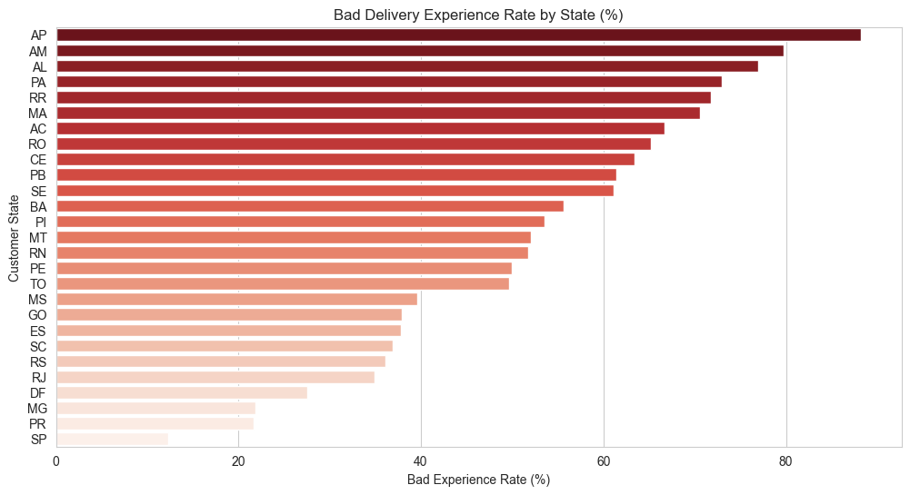

```python
orders_with_state_df = orders_df[['customer_state', 'delivery_time']].copy()
orders_with_state_df['delivery_time'] = pd.to_numeric(orders_with_state_df['delivery_time'], errors='coerce')
orders_with_state_df['delivery_group'] = orders_with_state_df['delivery_time'].apply(get_delivery_group)
orders_with_state_df = orders_with_state_df[orders_with_state_df['delivery_group'] != 'Unknown']

crosstab_ratio = pd.crosstab(
    index=orders_with_state_df['customer_state'],
    columns=orders_with_state_df['delivery_group'],
    normalize='index'
)

required_cols = ['Slow (16-30 days)', 'Very Slow (Long Tail)']
if all(col in crosstab_ratio.columns for col in required_cols):
    crosstab_ratio['Bad Experience Rate'] = (crosstab_ratio['Slow (16-30 days)'] + crosstab_ratio['Very Slow (Long Tail)']) * 100
else:
    print("Error: One of the required delivery groups ('Slow' or 'Very Slow') is missing.")

bad_experience_states = crosstab_ratio['Bad Experience Rate'].sort_values(ascending=False)

plt.figure(figsize=(12, 6))
sns.barplot(x=bad_experience_states.values, y=bad_experience_states.index, palette='Reds_r')
plt.title('Bad Delivery Experience Rate by State (%)')
plt.xlabel('Bad Experience Rate (%)')
plt.ylabel('Customer State')
plt.show()
```

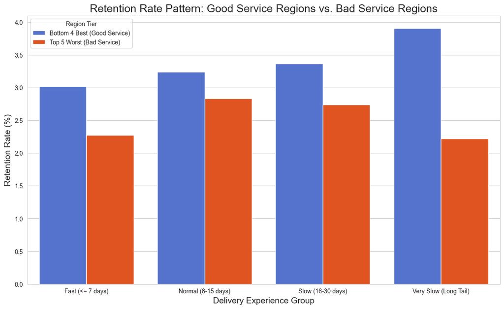

```
--- Chi-Squared Test for Independence ---
Contingency Table:
is_retained                       0     1
region_tier
Bottom 4 Best (Good Service)  56643  1859
Top 5 Worst (Bad Service)      1563    42

Chi-Squared Statistic: 1.4265
P-value: 0.2323

Conclusion: The p-value is not less than 0.05. We cannot conclude a statistically significant association.
```

```python
bad_experience_states = ['AP', 'AM', 'AL', 'PA', 'RR']
good_experience_states = ['DF', 'MG', 'PR', 'SP']

def assign_region_tier(state):
    if state in bad_experience_states:
        return 'Top 5 Worst (Bad Service)'
    elif state in good_experience_states:
        return 'Bottom 4 Best (Good Service)'
    else:
        return 'Other'

final_delivery_analysis_df['region_tier'] = final_delivery_analysis_df['customer_state'].apply(assign_region_tier)

comparison_df = final_delivery_analysis_df[final_delivery_analysis_df['region_tier'] != 'Other'].copy()

from scipy.stats import chi2_contingency

grouped_retention = comparison_df.groupby(['region_tier', 'delivery_group'])['is_retained'].agg(['mean', 'count']).reset_index()
grouped_retention['retention_rate'] = grouped_retention['mean'] * 100

group_order = ['Fast (<= 7 days)', 'Normal (8-15 days)', 'Slow (16-30 days)', 'Very Slow (Long Tail)']

plt.figure(figsize=(14, 8))
sns.barplot(
    x='delivery_group',
    y='retention_rate',
    hue='region_tier',
    data=grouped_retention,
    order=group_order,
    palette={'Top 5 Worst (Bad Service)': 'orangered', 'Bottom 4 Best (Good Service)': 'royalblue'}
)
plt.title('Retention Rate Pattern: Good Service Regions vs. Bad Service Regions', fontsize=18)
plt.ylabel('Retention Rate (%)', fontsize=14)
plt.xlabel('Delivery Experience Group', fontsize=14)
plt.legend(title='Region Tier')
plt.show()

contingency_table = pd.crosstab(comparison_df['region_tier'], comparison_df['is_retained'])

chi2, p_value, _, _ = chi2_contingency(contingency_table)

print("\n--- Chi-Squared Test for Independence ---")
print("Contingency Table:")
print(contingency_table)
print(f"\nChi-Squared Statistic: {chi2:.4f}")
print(f"P-value: {p_value:.4f}")

if p_value < 0.05:
    print("\nConclusion: The p-value is less than 0.05. We can conclude that there is a statistically significant association between the region's service level and customer retention.")
else:
    print("\nConclusion: The p-value is not less than 0.05. We cannot conclude a statistically significant association.")
```

### Analysis

- Retention rates are similar across all delivery speed groups (**~3%**).
- Faster delivery does **not** lead to higher retention.
- In fact, **very slow** deliveries show slightly higher retention in some regions.
- This suggests delivery speed alone is **not a key driver** of churn.
- Focus should shift to **deeper behavioral factors**, not just logistics speed.

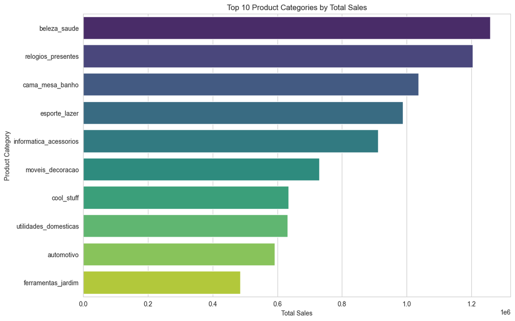

```python
query_products = """
SELECT p.product_category_name
     , SUM(oi.price) AS total_sales
FROM order_items oi
JOIN products p USING(product_id)
GROUP BY p.product_category_name
ORDER BY total_sales DESC
LIMIT 10;
"""

top_products_df = pd.read_sql_query(query_products, con)

plt.figure(figsize=(12, 8))
sns.barplot(x='total_sales', y='product_category_name', data=top_products_df, palette='viridis')
plt.title('Top 10 Product Categories by Total Sales')
plt.xlabel('Total Sales')
plt.ylabel('Product Category')
plt.show()
```

```python
query = """
SELECT oi.order_id
     , p.product_category_name
FROM order_items oi
INNER JOIN products p USING(product_id)
WHERE p.product_category_name IS NOT NULL
"""

first_order_items_df = pd.read_sql_query(query, con)

merged_df = pd.merge(first_orders_df, first_order_items_df, on='order_id')

display(merged_df.head())
```

|  | order_id | customer_id | order_status | order_purchase_timestamp | order_approved_at | order_delivered_carrier_date | order_delivered_customer_date | order_estimated_delivery_date | customer_unique_id | customer_zip_code_prefix | customer_city | customer_state | product_category_name |
| --- | --- | --- | --- | --- | --- | --- | --- | --- | --- | --- | --- | --- | --- |
| 0 | e22acc9c116caa3f2b7121bbb380d08e | fadbb3709178fc513abc1b2670aa1ad2 | delivered | 2018-05-10 10:56:27 | 2018-05-10 11:11:18 | 2018-05-12 08:18:00 | 2018-05-16 20:48:37 | 2018-05-21 | 0000366f3b9a7992bf8c76cfdf3221e2 | 7787 | cajamar | SP | cama_mesa_banho |
| 1 | 3594e05a005ac4d06a72673270ef9ec9 | 4cb282e167ae9234755102258dd52ee8 | delivered | 2018-05-07 11:11:27 | 2018-05-07 18:25:44 | 2018-05-09 12:18:00 | 2018-05-10 18:02:42 | 2018-05-15 | 0000b849f77a49e4a4ce2b2a4ca5be3f | 6053 | osasco | SP | beleza_saude |
| 2 | b33ec3b699337181488304f362a6b734 | 9b3932a6253894a02c1df9d19004239f | delivered | 2017-03-10 21:05:03 | 2017-03-10 21:05:03 | 2017-03-13 12:58:30 | 2017-04-05 14:38:47 | 2017-04-07 | 0000f46a3911fa3c0805444483337064 | 88115 | sao jose | SC | papelaria |
| 3 | 41272756ecddd9a9ed0180413cc22fb6 | 914991f0c02ef0843c0e7010c819d642 | delivered | 2017-10-12 20:29:41 | 2017-10-12 20:49:17 | 2017-10-13 20:08:19 | 2017-11-01 21:23:05 | 2017-11-13 | 0000f6ccb0745a6a4b88665a16c9f078 | 66812 | belem | PA | telefonia |
| 4 | d957021f1127559cd947b62533f484f7 | 47227568b10f5f58a524a75507e6992c | delivered | 2017-11-14 19:45:42 | 2017-11-14 20:06:52 | 2017-11-16 19:52:10 | 2017-11-27 23:08:56 | 2017-12-05 | 0004aac84e0df4da2b147fca70cf8255 | 18040 | sorocaba | SP | telefonia |

```python
customer_first_category_df = merged_df.drop_duplicates(subset=['customer_unique_id'])

display(customer_first_category_df.head())
```

|  | order_id | customer_id | order_status | order_purchase_timestamp | order_approved_at | order_delivered_carrier_date | order_delivered_customer_date | order_estimated_delivery_date | customer_unique_id | customer_zip_code_prefix | customer_city | customer_state | product_category_name |
| --- | --- | --- | --- | --- | --- | --- | --- | --- | --- | --- | --- | --- | --- |
| 0 | e22acc9c116caa3f2b7121bbb380d08e | fadbb3709178fc513abc1b2670aa1ad2 | delivered | 2018-05-10 10:56:27 | 2018-05-10 11:11:18 | 2018-05-12 08:18:00 | 2018-05-16 20:48:37 | 2018-05-21 | 0000366f3b9a7992bf8c76cfdf3221e2 | 7787 | cajamar | SP | cama_mesa_banho |
| 1 | 3594e05a005ac4d06a72673270ef9ec9 | 4cb282e167ae9234755102258dd52ee8 | delivered | 2018-05-07 11:11:27 | 2018-05-07 18:25:44 | 2018-05-09 12:18:00 | 2018-05-10 18:02:42 | 2018-05-15 | 0000b849f77a49e4a4ce2b2a4ca5be3f | 6053 | osasco | SP | beleza_saude |
| 2 | b33ec3b699337181488304f362a6b734 | 9b3932a6253894a02c1df9d19004239f | delivered | 2017-03-10 21:05:03 | 2017-03-10 21:05:03 | 2017-03-13 12:58:30 | 2017-04-05 14:38:47 | 2017-04-07 | 0000f46a3911fa3c0805444483337064 | 88115 | sao jose | SC | papelaria |
| 3 | 41272756ecddd9a9ed0180413cc22fb6 | 914991f0c02ef0843c0e7010c819d642 | delivered | 2017-10-12 20:29:41 | 2017-10-12 20:49:17 | 2017-10-13 20:08:19 | 2017-11-01 21:23:05 | 2017-11-13 | 0000f6ccb0745a6a4b88665a16c9f078 | 66812 | belem | PA | telefonia |
| 4 | d957021f1127559cd947b62533f484f7 | 47227568b10f5f58a524a75507e6992c | delivered | 2017-11-14 19:45:42 | 2017-11-14 20:06:52 | 2017-11-16 19:52:10 | 2017-11-27 23:08:56 | 2017-12-05 | 0004aac84e0df4da2b147fca70cf8255 | 18040 | sorocaba | SP | telefonia |

```python
final_category_df = pd.merge(customer_first_category_df, retention_df, on='customer_unique_id')

display(final_category_df[['customer_unique_id', 'product_category_name', 'is_retained']].head())
```

|  | customer_unique_id | product_category_name | is_retained |
| --- | --- | --- | --- |
| 0 | 0000366f3b9a7992bf8c76cfdf3221e2 | cama_mesa_banho | 0 |
| 1 | 0000b849f77a49e4a4ce2b2a4ca5be3f | beleza_saude | 0 |
| 2 | 0000f46a3911fa3c0805444483337064 | papelaria | 0 |
| 3 | 0000f6ccb0745a6a4b88665a16c9f078 | telefonia | 0 |
| 4 | 0004aac84e0df4da2b147fca70cf8255 | telefonia | 0 |

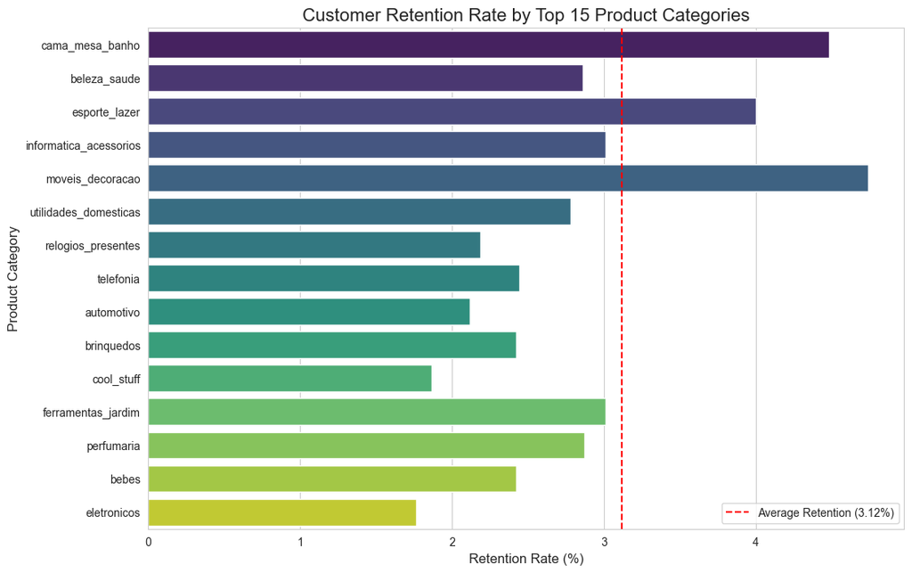

```python
retention_by_category = final_category_df.groupby('product_category_name')['is_retained'].mean()

category_counts = final_category_df['product_category_name'].value_counts()

retention_analysis = pd.DataFrame({
    'retention_rate' : retention_by_category * 100,
    'customer_count' : category_counts
}).dropna().sort_values(by='customer_count', ascending=False).head(15)

plt.figure(figsize=(12, 8))
sns.barplot(x='retention_rate', y=retention_analysis.index, data=retention_analysis, palette='viridis')
plt.title('Customer Retention Rate by Top 15 Product Categories', fontsize=16)
plt.xlabel('Retention Rate (%)', fontsize=12)
plt.ylabel('Product Category', fontsize=12)
plt.axvline(x=3.12, color='red', linestyle='--', label='Average Retention (3.12%)')
plt.legend()
plt.show()
```

Next: Testing **Payment Issue**, our last suspect.

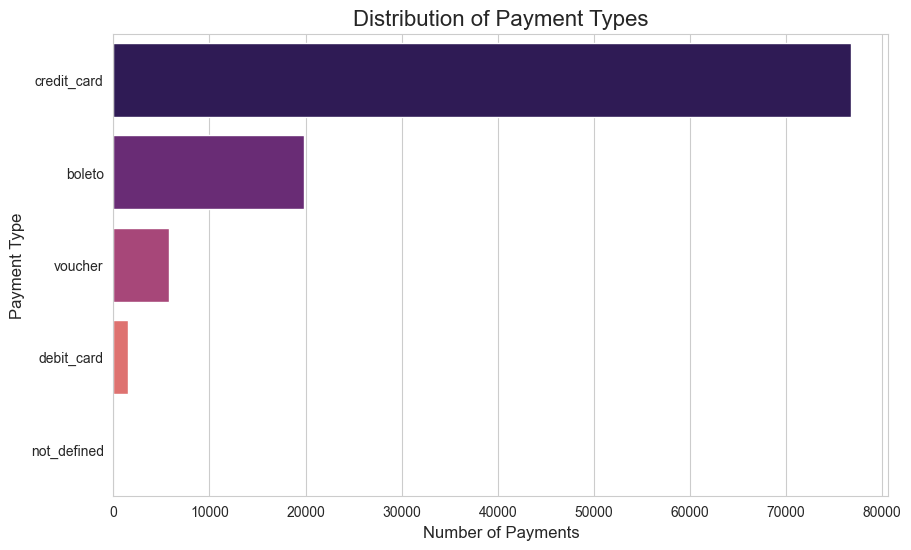

```python
query = """
SELECT order_id
     , payment_type
     , COUNT(*) AS cnt
FROM order_payments
GROUP BY payment_type
ORDER BY cnt DESC;
"""

payments_df = pd.read_sql_query(query, con)

sns.set_style('whitegrid')
plt.figure(figsize=(10, 6))
sns.barplot(x='cnt', y='payment_type', data=payments_df, palette='magma')
plt.title('Distribution of Payment Types', fontsize=16)
plt.xlabel('Number of Payments', fontsize=12)
plt.ylabel('Payment Type', fontsize=12)
plt.show()
```

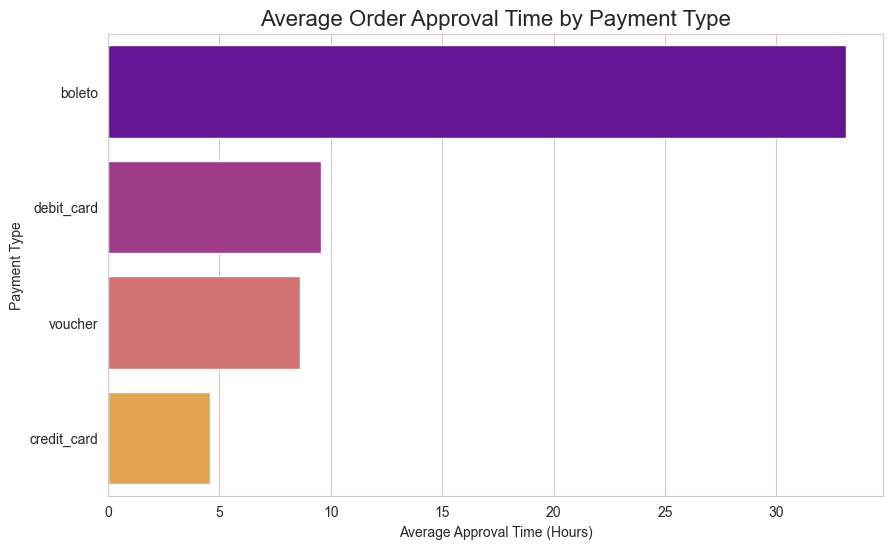

```python
query = """
SELECT o.order_purchase_timestamp
     , o.order_approved_at
     , p.payment_type
FROM orders o
INNER JOIN order_payments p USING(order_id)
WHERE o.order_approved_at IS NOT NULL;
"""

approval_df = pd.read_sql_query(query, con)

approval_df['order_purchase_timestamp'] = pd.to_datetime(approval_df['order_purchase_timestamp'])
approval_df['order_approved_at'] = pd.to_datetime(approval_df['order_approved_at'])

approval_df['approval_time_hours'] = (approval_df['order_approved_at'] - approval_df['order_purchase_timestamp']).dt.total_seconds()/3600

avg_approval_time = approval_df.groupby('payment_type')['approval_time_hours'].mean().sort_values(ascending=False)

plt.figure(figsize=(10, 6))
sns.barplot(x=avg_approval_time.values, y=avg_approval_time.index, palette='plasma')
plt.title('Average Order Approval Time by Payment Type', fontsize=16)
plt.xlabel('Average Approval Time (Hours)')
plt.ylabel('Payment Type')
plt.show()
```

```python
payment_query = """
SELECT
    order_id,
    payment_type
FROM
    order_payments
"""
payments_1_df = pd.read_sql_query(payment_query, con)


first_order_payment_df = pd.merge(first_orders_df, payments_1_df, on='order_id', how='left')

first_order_payment_df.drop_duplicates(subset=['customer_unique_id'], keep='first', inplace=True)

final_payment_df = pd.merge(first_order_payment_df, retention_df, on='customer_unique_id')

display(final_payment_df[['customer_unique_id', 'payment_type', 'is_retained']].head(100))
```

|  | customer_unique_id | payment_type | is_retained |
| --- | --- | --- | --- |
| 0 | 0000366f3b9a7992bf8c76cfdf3221e2 | credit_card | 0 |
| 1 | 0000b849f77a49e4a4ce2b2a4ca5be3f | credit_card | 0 |
| 2 | 0000f46a3911fa3c0805444483337064 | credit_card | 0 |
| 3 | 0000f6ccb0745a6a4b88665a16c9f078 | credit_card | 0 |
| 4 | 0004aac84e0df4da2b147fca70cf8255 | credit_card | 0 |
| ... | ... | ... | ... |
| 95 | 003c2067070f5b3d923235b1ea1cc17b | boleto | 0 |
| 96 | 003c457932a554e4df13834237b1ed00 | boleto | 0 |
| 97 | 003d56767e53e08671de00da3fba8d40 | credit_card | 0 |
| 98 | 003db7adfcdc49857b095a50191b6c9d | credit_card | 0 |
| 99 | 003e28cb6fab8a0901bff9229612375f | credit_card | 0 |

100 rows × 3 columns

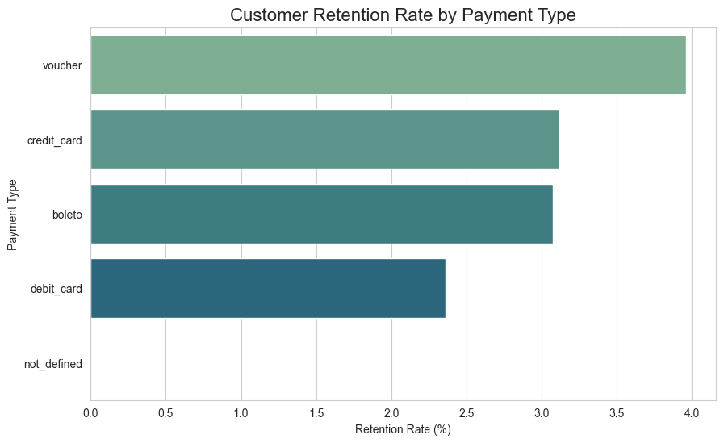

```python
retention_by_payment = final_payment_df.groupby('payment_type')['is_retained'].mean().sort_values(ascending=False) * 100

plt.figure(figsize=(10, 6))
sns.barplot(x=retention_by_payment.values, y=retention_by_payment.index, palette='crest')
plt.title('Customer Retention Rate by Payment Type', fontsize=16)
plt.xlabel('Retention Rate (%)')
plt.ylabel('Payment Type')
plt.show()
```

### Analysis

- Retention stays under 4% across all payment types.
- No meaningful variation → **payment method has minimal impact** on churn.

### 3-2. Insight: Why Move Beyond Single-Variable Analysis?

- Delivery speed and payment method alone do **not fully explain** churn.
- Customer behavior is likely shaped by **combinations of factors** (e.g., region × delivery × product).
- Simple analysis misses **non-linear effects** and **hidden interactions**.
- A machine learning model can help reveal these patterns and measure the **true drivers of retention**.

```python
from sklearn.model_selection import train_test_split
from sklearn.preprocessing import StandardScaler
import numpy as np

order_items_df = pd.read_sql_query("SELECT * FROM order_items", con)
products_df = pd.read_sql_query("SELECT * FROM products", con)
order_payments_df = pd.read_sql_query("SELECT * FROM order_payments", con)

all_orders_with_delivery_info = orders_df[orders_df['delivery_time'].notna()].copy()
first_purchase_info = all_orders_with_delivery_info.sort_values('order_purchase_timestamp').drop_duplicates('customer_unique_id', keep='first')

model_df = pd.merge(first_purchase_info, retention_df, on='customer_unique_id')
model_df = pd.merge(model_df, order_items_df, on='order_id', how='left')
model_df = pd.merge(model_df, products_df, on='product_id', how='left')
model_df = pd.merge(model_df, order_payments_df, on='order_id', how='left')

model_df.drop_duplicates(subset='order_id', keep='first', inplace=True)
display(model_df.info())
```

```
<class 'pandas.core.frame.DataFrame'>
Index: 93356 entries, 0 to 111008
Data columns (total 34 columns):
 #   Column                         Non-Null Count  Dtype
---  ------                         --------------  -----
 0   order_id                       93356 non-null  object
 1   customer_id                    93356 non-null  object
 2   order_status                   93356 non-null  object
 3   order_purchase_timestamp       93356 non-null  datetime64[ns]
 4   order_approved_at              93342 non-null  datetime64[ns]
 5   order_delivered_carrier_date   93355 non-null  datetime64[ns]
 6   order_delivered_customer_date  93356 non-null  datetime64[ns]
 7   order_estimated_delivery_date  93356 non-null  datetime64[ns]
 8   customer_unique_id             93356 non-null  object
 9   customer_zip_code_prefix       93356 non-null  int64
```

[output cut: 26 more lines]

```
None
```

```python
model_df.dropna(
    subset=['delivery_time', 'price', 'freight_value', 'product_category_name', 'customer_state', 'payment_type', 'is_retained'], inplace=True
)

features_to_use = [
    'delivery_time',
    'price',
    'freight_value',
    'product_category_name',
    'customer_state',
    'payment_type'
]

target = 'is_retained'

X = model_df[features_to_use]
y = model_df[target]
print(f"Prepared data with {X.shape[0]} samples and {X.shape[1]} initial features.")

X_encoded = pd.get_dummies(X, columns=['customer_state', 'product_category_name', 'payment_type'], drop_first=True)

X_train, X_test, y_train, y_test = train_test_split(
    X_encoded, y,
    test_size=0.2,
    random_state=42,
    stratify=y
)

display(X_train.head())
```

```
Prepared data with 92040 samples and 6 initial features.
```

|  | delivery_time | price | freight_value | customer_state_AL | customer_state_AM | customer_state_AP | customer_state_BA | customer_state_CE | customer_state_DF | customer_state_ES | ... | product_category_name_relogios_presentes | product_category_name_seguros_e_servicos | product_category_name_sinalizacao_e_seguranca | product_category_name_tablets_impressao_imagem | product_category_name_telefonia | product_category_name_telefonia_fixa | product_category_name_utilidades_domesticas | payment_type_credit_card | payment_type_debit_card | payment_type_voucher |
| --- | --- | --- | --- | --- | --- | --- | --- | --- | --- | --- | --- | --- | --- | --- | --- | --- | --- | --- | --- | --- | --- |
| 60955 | 13.0 | 309.99 | 15.90 | False | False | False | False | False | False | False | ... | False | False | False | False | False | False | False | True | False | False |
| 9632 | 8.0 | 119.99 | 14.57 | False | False | False | False | False | False | False | ... | False | False | False | False | False | False | False | True | False | False |
| 36246 | 8.0 | 9.90 | 11.85 | False | False | False | False | False | False | False | ... | False | False | False | False | False | False | True | True | False | False |
| 14309 | 19.0 | 99.99 | 16.46 | False | False | False | False | False | False | False | ... | False | False | False | False | False | False | False | False | False | False |
| 33953 | 2.0 | 85.90 | 14.33 | False | False | False | False | False | False | False | ... | False | False | False | False | False | False | False | True | False | False |

5 rows × 104 columns

```python
from sklearn.linear_model import LogisticRegression
from sklearn.ensemble import RandomForestClassifier
import xgboost as xgb
from sklearn.metrics import roc_auc_score, f1_score, precision_score, recall_score, confusion_matrix
import shap

scale_pos_weight = y_train.value_counts()[0] / y_train.value_counts()[1]

models = {
    "Logistic Regression": LogisticRegression(random_state=42, class_weight='balanced', max_iter=1000),
    "Random Forest": RandomForestClassifier(random_state=42, class_weight='balanced'),
    "XGBoost": xgb.XGBClassifier(
        objective='binary:logistic',
        eval_metric='logloss',
        scale_pos_weight=scale_pos_weight,
        use_label_encoder=False,
        random_state=42
    )
}
results = {}

for name, model in models.items():
    print(f"Training {name}...")
    model.fit(X_train, y_train)

    y_pred = model.predict(X_test)
    y_pred_proba = model.predict_proba(X_test)[:, 1]

    roc_auc = roc_auc_score(y_test, y_pred_proba)
    f1 = f1_score(y_test, y_pred)
    precision = precision_score(y_test, y_pred)
    recall = recall_score(y_test, y_pred)

    results[name] = {
        "ROC AUC": roc_auc,
        "F1 Score": f1,
        "Precision": precision,
        "Recall": recall
    }
    print(f"-> {name} evaluation complete.")

    results_df = pd.DataFrame(results).T.sort_values(by="ROC AUC", ascending=False)

    display(results_df)
```

```
Training Logistic Regression...
-> Logistic Regression evaluation complete.
```

|  | ROC AUC | F1 Score | Precision | Recall |
| --- | --- | --- | --- | --- |
| Logistic Regression | 0.577343 | 0.074778 | 0.040445 | 0.494898 |

```
Training Random Forest...
-> Random Forest evaluation complete.
```

|  | ROC AUC | F1 Score | Precision | Recall |
| --- | --- | --- | --- | --- |
| Logistic Regression | 0.577343 | 0.074778 | 0.040445 | 0.494898 |
| Random Forest | 0.542385 | 0.008902 | 0.034884 | 0.005102 |

```
Training XGBoost...
```

```
-> XGBoost evaluation complete.
```

|  | ROC AUC | F1 Score | Precision | Recall |
| --- | --- | --- | --- | --- |
| Logistic Regression | 0.577343 | 0.074778 | 0.040445 | 0.494898 |
| XGBoost | 0.575378 | 0.078754 | 0.043785 | 0.391156 |
| Random Forest | 0.542385 | 0.008902 | 0.034884 | 0.005102 |

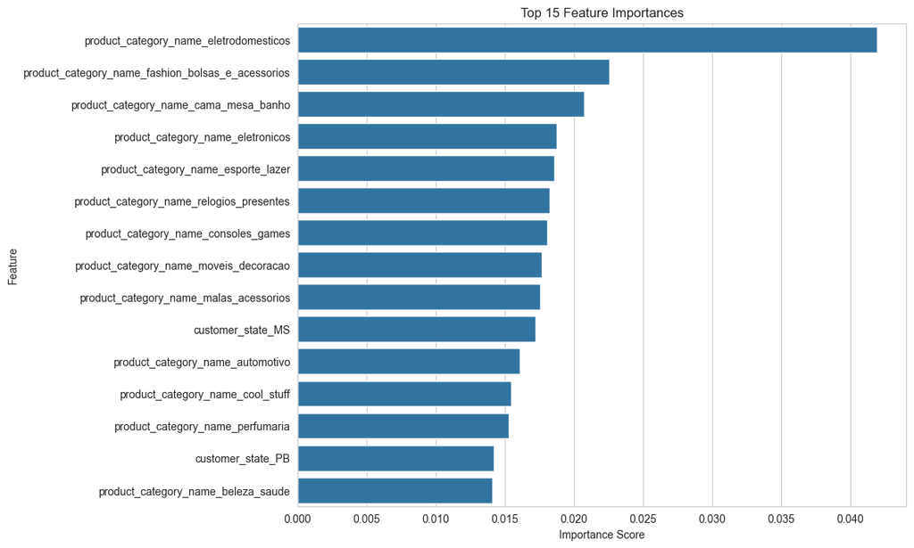

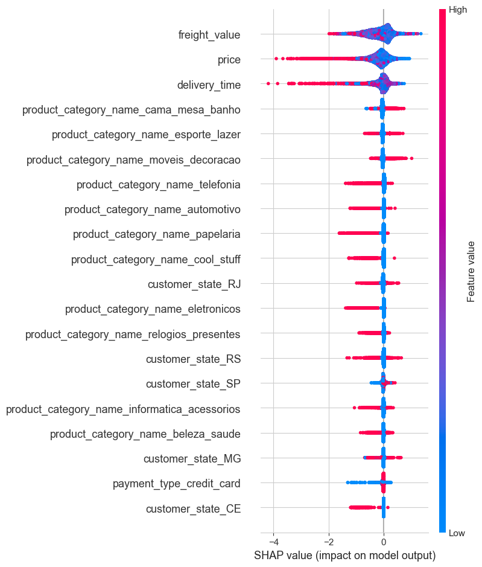

```python
final_model = xgb.XGBClassifier(
    objective ='binary:logistic',
    eval_metric='logloss',
    scale_pos_weight=scale_pos_weight,
    use_label_encoder=False,
    random_state=42
)

final_model.fit(X_train, y_train)
feature_importances = pd.Series(final_model.feature_importances_,index=X_train.columns).sort_values(ascending=False)

plt.figure(figsize=(10, 8))
sns.barplot(x=feature_importances.head(15), y=feature_importances.head(15).index)
plt.title('Top 15 Feature Importances')
plt.xlabel('Importance Score')
plt.ylabel('Feature')
plt.show()

explainer = shap.TreeExplainer(final_model)
shap_values = explainer.shap_values(X_test)

shap.summary_plot(shap_values, X_test)
```

### 4. Final Insights & Recommendations

We built a machine learning model to understand why customers do not return. To explain the model's logic, we used two techniques:

#### Part 1: Feature Importance

**Question:** What information did the model use the most?

- The model mostly used **Product Category** and **Customer Location** to make predictions.
- This shows which features the model paid attention to, but not whether they helped or hurt retention.

#### Part 2: SHAP Analysis

**Question:** How does each factor impact each customer's chance of returning?

### Actionable Recommendations

- **What:** Promote the cama_mesa_banho category.
- **How:** Cross-sell and recommend these products to both existing and new users.

#### 3. Regional Targeting

- **What:** Treat regions differently based on retention rates.
- **How:**
  - For strong regions (e.g., SP, RJ): Launch VIP programs.
  - For weaker regions: Focus on first-purchase satisfaction and delivery speed guarantees.